# Homework #4

Gavin Herum

10/17/2022

## Chick weights

The `ChickWeight` data set is part of the base package `datasets`. See `?ChickWeight` for details on the data. For all of the questions use `dplyr` functions whenever possible.

1. Download the RMarkdown file with these homework instructions to use as a template for your work. Make sure to replace “Your Name” in the YAML with your name. To get full points, show your R code (in a code chunk) and write answers to the questions.
2. (1 pt) What variables are part of the dataset?

   ```r
   data("ChickWeight")
   ?ChickWeight
   ```

   ```
   ## starting httpd help server ... done
   ```

   The data set has a **weight** variable that stores the given body weight of a chick in grams. A **Time** variable tracking the time since birth for the measurement. A **Chick** variable to identify which chick the data belongs to. And a **Diet** variable indicating which diet the chick was on.
3. (2 pts) Get a frequency breakdown of the number of chicks, their average weight and the standard deviation of the weights in each of the diets at the start of the study.  
   0.5 pts of extra credit: construct a ggplot that shows average weights by diet with an interval (shown as a line) of +- the standard deviation around the averages. (Hint: read this article regarding [ggplot error bars](http://www.sthda.com/english/wiki/ggplot2-error-bars-quick-start-guide-r-software-and-data-visualization))

```r
library(ggplot2)
library(base)
library(stats)
library(dplyr)
# Calculate average weight and standard deviation by diet
diet_summary <- ChickWeight %>%
  group_by(Diet) %>%
  summarize(avg_weight = mean(weight),
            sd_weight = sd(weight))

diet_summary
```

```
## # A tibble: 4 × 3
##   Diet  avg_weight sd_weight
##   <fct>      <dbl>     <dbl>
## 1 1           103.      56.7
## 2 2           123.      71.6
## 3 3           143.      86.5
## 4 4           135.      68.8
```

1. (2.5 pts) Each chick should have twelve weight measurements. Use the dplyr package to identify how many chicks have a complete set of weight measurements and how many measurements there are on average in the incomplete cases. Extract a subset of the data for all chicks with complete information and name the data set `complete`. (Hint: you might want to use mutate to introduce a helper variable consisting of the number of observations)

   ```r
   # First, let's calculate the number of measurements for each chick
   chicks_data <- ChickWeight %>%
     group_by(Chick) %>%
     mutate(num_measurements = n())

   # Identify how many chicks have a complete set of weight measurements
   complete_chicks <- chicks_data %>%
     filter(num_measurements == 12)

   # Calculate the number of measurements on average in the incomplete cases
   incomplete_avg <- chicks_data %>%
     filter(num_measurements != 12) %>%
     summarize(avg_measurements = mean(num_measurements))

   # Extract a subset of the data for all chicks with complete information
   complete <- chicks_data %>%
     filter(num_measurements == 12)
   ```

2. (.5 pt) In the complete data set introduce a new variable that measures the current weight difference compared to day 0. Name this variable `weightgain`. (Hint: use mutate and `?mutate` to check the parameter `.by`. This parameter can create a temporary `group_by` so that we can do calculation in each subgroup, i.e. for each combination of chick and diet, `weight - min(weight)`)

```r
complete <- complete %>%
  group_by(Chick, Diet) %>%
  mutate(weightgain = weight - min(weight))

complete
```

```
## # A tibble: 540 × 6
## # Groups:   Chick, Diet [45]
##    weight  Time Chick Diet  num_measurements weightgain
##     <dbl> <dbl> <ord> <fct>            <int>      <dbl>
##  1     42     0 1     1                   12          0
##  2     51     2 1     1                   12          9
##  3     59     4 1     1                   12         17
##  4     64     6 1     1                   12         22
##  5     76     8 1     1                   12         34
##  6     93    10 1     1                   12         51
##  7    106    12 1     1                   12         64
##  8    125    14 1     1                   12         83
##  9    149    16 1     1                   12        107
## 10    171    18 1     1                   12        129
## # ℹ 530 more rows
```

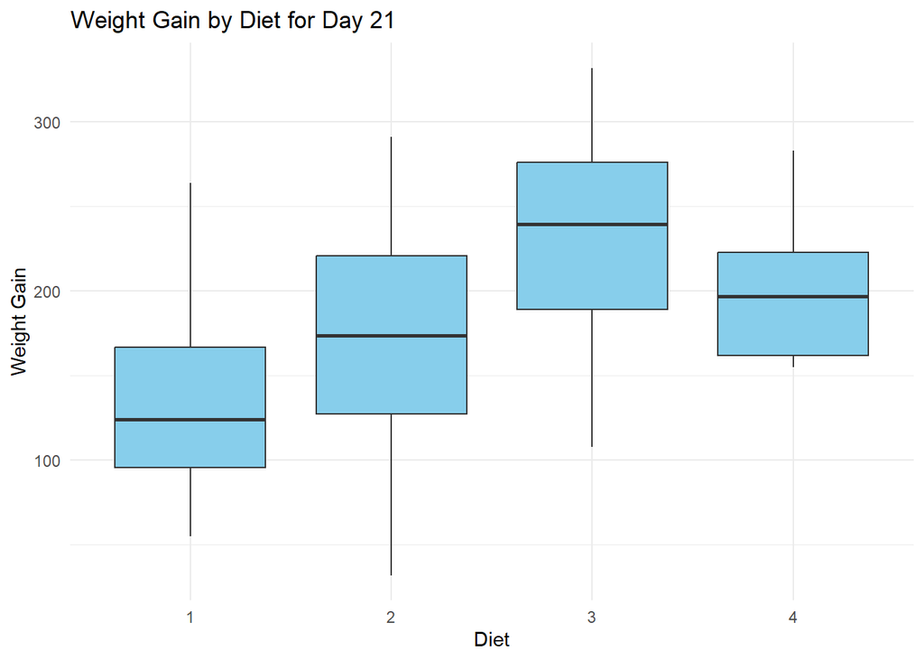

   ```r
   complete <- complete %>%
     mutate(Diet = factor(Diet, levels = levels(Diet)[order(tapply(weightgain, Diet, median))]))

   # Filter data for day 21
   day_21_data <- complete %>%
     filter(Time == 21)

   # Create boxplot
   ggplot(day_21_data, aes(x = Diet, y = weightgain)) +
     geom_boxplot(fill = "skyblue") +
     labs(title = "Weight Gain by Diet for Day 21",
          x = "Diet",
          y = "Weight Gain") +
     theme_minimal()
   ```

Note: 1.5 pts your submission is supposed to be fully reproducible, i.e. the TA and I will ‘knit’ your submission in RStudio.

For the submission: submit your solution in an R Markdown file and (just for insurance) submit the corresponding html (or Word) file with it.